# Personal finance

```python
import numpy as np
import pandas as pd
import matplotlib.pyplot as plt
```

## Raw data from Wells Fargo

```python
expenses = pd.read_csv("CreditCard2.csv")
expenses
```

|  | 04/08/2024 | -4.75 | * | Unnamed: 3 | SQ *SEISMIC COFFEE Emeryville CA |
| --- | --- | --- | --- | --- | --- |
| 0 | 04/07/2024 | 25.00 | * | NaN | AUTOMATIC PAYMENT - THANK YOU |
| 1 | 04/06/2024 | -41.52 | * | NaN | FREE PEOPLE #821 WALNUT CREEK CA |
| 2 | 04/06/2024 | -10.88 | * | NaN | ULTA #353 BRENTWOOD CA |
| 3 | 04/06/2024 | -34.96 | * | NaN | BRANDY MELVILLE - WALNUT 310-7735405 CA |
| 4 | 04/06/2024 | -4.10 | * | NaN | SQ *BIG HOUSE BEANS Brentwood CA |
| ... | ... | ... | ... | ... | ... |
| 110 | 01/12/2024 | -15.50 | * | NaN | INTEREST CHARGE ON PURCHASES |
| 111 | 01/07/2024 | 25.00 | * | NaN | AUTOMATIC PAYMENT - THANK YOU |
| 112 | 12/24/2023 | -229.00 | * | NaN | CorePower Yoga - Shtck Berkeley CA |
| 113 | 12/21/2023 | -0.95 | * | NaN | FOREIGN CURRENCY CONVERSION FEE |
| 114 | 12/21/2023 | -31.81 | * | NaN | DNH*GODADDY.COM 480-5058855 AZ |

115 rows × 5 columns

## Cleaning

```python
expenses.columns = ["Date", "Amount", "delete", "delete1", "Purchase"]
```

```python
expenses = expenses.drop(['delete', 'delete1'], axis=1)
expenses
```

|  | Date | Amount | Purchase |
| --- | --- | --- | --- |
| 0 | 04/07/2024 | 25.00 | AUTOMATIC PAYMENT - THANK YOU |
| 1 | 04/06/2024 | -41.52 | FREE PEOPLE #821 WALNUT CREEK CA |
| 2 | 04/06/2024 | -10.88 | ULTA #353 BRENTWOOD CA |
| 3 | 04/06/2024 | -34.96 | BRANDY MELVILLE - WALNUT 310-7735405 CA |
| 4 | 04/06/2024 | -4.10 | SQ *BIG HOUSE BEANS Brentwood CA |
| ... | ... | ... | ... |
| 110 | 01/12/2024 | -15.50 | INTEREST CHARGE ON PURCHASES |
| 111 | 01/07/2024 | 25.00 | AUTOMATIC PAYMENT - THANK YOU |
| 112 | 12/24/2023 | -229.00 | CorePower Yoga - Shtck Berkeley CA |
| 113 | 12/21/2023 | -0.95 | FOREIGN CURRENCY CONVERSION FEE |
| 114 | 12/21/2023 | -31.81 | DNH*GODADDY.COM 480-5058855 AZ |

115 rows × 3 columns

## Categorizing my purchases

Is there any AI I can use to do this? I'm just using brute force. Dropping in keywords and categorizing that way but there has to some way I can automate this right?

```python
purchases = np.array(expenses['Purchase'])
```

```python
def categorize(purchase):
    if "CLIPPER" in purchase:
        return "transportation"
    if "CAFE" in purchase or "COFFEE" in purchase or "STRADA" in purchase or "NORMAL" in purchase or "BEANS" in purchase:
        return "coffee"
    if "TRADER" in purchase:
        return "trader joes"
    if "BRANDY" in purchase or "FREE PEOPLE" in purchase or "URBAN" in purchase or "ZARA" in purchase or "HAT" in purchase:
        return "clothes"
    if "Yoga" in purchase:
        return "yoga"
    if "WAX" in purchase or "ax" in purchase or "PARLOR" in purchase:
        return "wax or threading"
    if "CINEMA" in purchase:
        return "movie"
    if "CHEESE" in purchase or "SWEETGREEN" in purchase or "POKE" in purchase or "SQ" in purchase or "CKE" in purchase:
        return "food"
    if "ARCO" in purchase or "76" in purchase or "PARK" in purchase:
        return "gas/parking"
    if "CHARGE" in purchase:
        return "interest charge"
    if "FEE" in purchase:
        return "fee"
    if "GODADDY" in purchase:
        return "domain"
    if "ULTA" in purchase or "WHOLE" in purchase or "TARGET" in purchase or "FOOD CO" in purchase:
        return "misc"
    return str(purchase)
```

```python
categories = []

for purchase in purchases:
    categories.append(categorize(purchase))
```

## Aggregating

I'm gonna aggregate categories to get total amounts.

```python
expenses['Category'] = categories
```

```python
s = expenses["Amount"].groupby(expenses["Category"]).sum()
```

```python
grouped_expenses = s.reset_index(name='amount')
grouped_expenses
```

|  | Category | amount |
| --- | --- | --- |
| 0 | AUTOMATIC PAYMENT - THANK YOU | 75.00 |
| 1 | ONLINE PAYMENT THANK YOU | 1048.92 |
| 2 | clothes | -225.29 |
| 3 | coffee | -178.60 |
| 4 | domain | -31.81 |
| 5 | fee | -0.95 |
| 6 | food | -101.99 |
| 7 | gas/parking | -42.73 |
| 8 | interest charge | -31.94 |
| 9 | misc | -24.04 |
| 10 | movie | -34.78 |
| 11 | trader joes | -168.25 |
| 12 | transportation | -470.00 |
| 13 | wax or threading | -206.95 |
| 14 | yoga | 0.00 |

#### I spent 178 bucks on coffee. I have no words. Just shame.

Let's drop the positive numbers and the 0 for yoga so we only have purchases (corepower refunded me).

```python
grouped_expenses = grouped_expenses[grouped_expenses["amount"] < 0]
grouped_expenses
```

|  | Category | amount |
| --- | --- | --- |
| 2 | clothes | -225.29 |
| 3 | coffee | -178.60 |
| 4 | domain | -31.81 |
| 5 | fee | -0.95 |
| 6 | food | -101.99 |
| 7 | gas/parking | -42.73 |
| 8 | interest charge | -31.94 |
| 9 | misc | -24.04 |
| 10 | movie | -34.78 |
| 11 | trader joes | -168.25 |
| 12 | transportation | -470.00 |
| 13 | wax or threading | -206.95 |

## Sorting

```python
sorted_expenses = grouped_expenses.sort_values(by='amount')
sorted_expenses
```

|  | Category | amount |
| --- | --- | --- |
| 12 | transportation | -470.00 |
| 2 | clothes | -225.29 |
| 13 | wax or threading | -206.95 |
| 3 | coffee | -178.60 |
| 11 | trader joes | -168.25 |
| 6 | food | -101.99 |
| 7 | gas/parking | -42.73 |
| 10 | movie | -34.78 |
| 8 | interest charge | -31.94 |
| 4 | domain | -31.81 |
| 9 | misc | -24.04 |
| 5 | fee | -0.95 |

```python
# total spent
total = np.abs(sorted_expenses['amount'].sum())
total
```

```
1517.33
```

Adding a column for percentage out of total spent.

```python
sorted_expenses["percentage"] = np.abs(sorted_expenses["amount"] / total)
```

```python
sorted_expenses
```

|  | Category | amount | percentage |
| --- | --- | --- | --- |
| 12 | transportation | -470.00 | 0.309755 |
| 2 | clothes | -225.29 | 0.148478 |
| 13 | wax or threading | -206.95 | 0.136391 |
| 3 | coffee | -178.60 | 0.117707 |
| 11 | trader joes | -168.25 | 0.110886 |
| 6 | food | -101.99 | 0.067217 |
| 7 | gas/parking | -42.73 | 0.028161 |
| 10 | movie | -34.78 | 0.022922 |
| 8 | interest charge | -31.94 | 0.021050 |
| 4 | domain | -31.81 | 0.020964 |
| 9 | misc | -24.04 | 0.015844 |
| 5 | fee | -0.95 | 0.000626 |

## Visuals

I'll make a pie chart cause WHY NOT.

```python
to_plot_df = sorted_expenses[["percentage"]]
to_plot_df.index = sorted_expenses['Category']
```

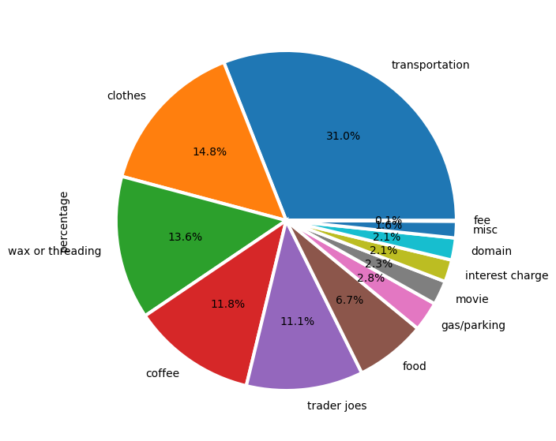

```python
plot = to_plot_df.plot.pie(y='percentage', figsize = (7,7), autopct='%1.1f%%', wedgeprops = {
    'linewidth' : 3, 'edgecolor' : 'white' })
plot.get_legend().remove()
```

#### Ok. This is all I can muster. In summary:

Transportation is a fixed cost and I can't change it. But considering everything else I'm not spending money on this semester, I'm okay with this.

11.8 percent of my spending CANNOT BE COFFEE! The thing is I get used to picking up americanos on campus when I'm falling asleep looking at a screen, but I must stop. Or just make it at home. Or reduce caffeine intake. Gah.

The wax/threading I get but it's a bit much.

I get the clothes but I can calm down.

Trader joes I also get and have calmed down a great deal. If I pulled up expenses from last semester or the summer before, the trader joes slice would've been huge. I'm a sucker for that grocery store. But I can and should switch.

I'm proud of the food percentage. I've been pretty conscious about not eating out this semester.

Everything else I don't really care about.